# R Notebook

1 Analytical methodologies

The exploratory data analysis in Assignment_1 indicates several findings and issues (1) The target score is a continuous variable and the distribution of the target score is bell-shaped. (2) The datasets provides abundant information and various kinds of features. (3) Some important features have low linear correlation with the target loyalty score, which indicates that two variable are linear independent, while these features may have other complicated relations. (4) The data source does not show logic and computational process behind the target loyalty score and the dataset description hides real names of many features as they are confidential business information. This may add difficulties on selecting features and interpreting the model.

According to the findings and issues, the research question should be answered by regression algorithms that predicts the customer loyalty score. There are several steps: (1) Work on the dataset by removing outliers and preprocessing some categorical features; (2) Split dataset into two parts: 80% training data for training models and 20% test data for testing the model; (3) Compare two tree based algorithms - Random Forest (RF) and Gradient Boosting Decision Tree (GBDT). RF can deal with high dimensional dataset without feature selection because the feature subsets are randomly selected. After training, it can gives out the importance ranking of features. GBDT uses regression decision trees as weak learner. Trees are added one at a time and a gradient descent procedure is used to minimize the loss; (4) Visualize the feature importance ranking and residuals of the two algorithms; (5) Use root mean square error (RMSE) as the evaluation method to measure the performance of models.

The model can predict the loyalty score for the research question. The ranking of importance can answer the question which features are relevant to the loyalty score.

2 Implement the methodologies

2.1 Load and preprocess the data

```r
#Read csv file to R as flat frame because some datasets are too large (1.3 Gb)

library(ff)
```

```r
HisTranData <- read.csv.ffdf(file = "/Users/apple/Mcgill/692IntroDataScience/kaggleProject/elo-merchant-category-recommendation/historical_transactions.csv", header = TRUE)

#NewTranData <- read.csv.ffdf(file = "/Users/apple/Mcgill/692IntroDataScience/kaggleProject/elo-merchant-category-recommendation/new_merchant_transactions.csv", header = TRUE)

#MerchantData <-read.csv.ffdf(file = "/Users/apple/Mcgill/692IntroDataScience/kaggleProject/elo-merchant-category-recommendation/merchants.csv", header = TRUE)
```

```r
#Load the train dataset

TrainData <- read.csv(file = "/Users/apple/Mcgill/692IntroDataScience/kaggleProject/elo-merchant-category-recommendation/train.csv", header = TRUE, nrows = 20000)
```

```r
# Create subsets of historical transaction dataset according to train dataset

HistoricalData <- subset(as.data.frame(HisTranData), card_id%in% TrainData$card_id )

rm(HisTranData)
#NewData <- subset(as.data.frame(NewTranData), card_id%in% TrainData$card_id )

#MerchData <- subset(as.data.frame(MerchantData), (merchant_id%in% HistoricalData$merchant_id)| (merchant_id%in%NewData$merchant_id))
```

```r
#The feature "authorized_flag": Y' if approved, 'N' if denied
#Filter historical transactions that are authorized

library(dplyr)
library(tidyr)

hist_data_process <- subset(HistoricalData, authorized_flag == "Y")

dates <- format(as.Date(hist_data_process$purchase_date), "%Y-%m")

#Add a new feature purchase_month

hist_data_process["purchase_month"] <- dates

#In the historical transaction dataset, one card_id has hundreds of transactions. Summarize the transactions by frequency, amount category and the duration (latest purchase date - earlest purchase date)

library(data.table)
dt_temp <- data.table(hist_data_process)

dt_hist <- dt_temp[, list(
  purchase_amount_sum = sum(purchase_amount),
  purchase_amount_mean = mean(purchase_amount),
  purchase_freq = .N,
  installments_mean = mean(installments),
  purchase_max_diff = max(month_lag) - min(month_lag),
  purchase_latest_month = max(purchase_month),
  purchase_earlest_month = min(purchase_month),
  category_1_Y = length(which(category_1 == "Y")),
  category_1_N = length(which(category_1 == "N")),
  category_2_1 = length(which(category_2 == "1")),
  category_2_2 = length(which(category_2 == "2")),
  category_2_3 = length(which(category_2 == "3")),
  category_2_4 = length(which(category_2 == "4")),
  category_2_5 = length(which(category_2 == "5")),
  category_3_A = length(which(category_3 == "A")),
  category_3_B = length(which(category_3 == "B")),
  category_3_C = length(which(category_3 == "C")) ), by = c("card_id")]

rm(dt_temp)
rm(dates)
rm(HistoricalData)
```

```r
#Drop outliers(records where loyalty score <-30) as in Assignment_1

dt_train <- data.table(subset(TrainData, target > -30 ))

rm(TrainData)
```

```r
#Join the train dataset and transaction dataset by card id

setkey(dt_hist, card_id)
setkey(dt_train, card_id)

merge_hist <-dt_train[dt_hist,nomatch = 0]
```

```r
#The feature "first_active_month":  'YYYY-MM', month of first active use from training data

#The feature "purchase_earlest_month": month of first purchase from historical transactions data

#Add a new column to judge if the purchase_earlest_month  is larger (later) than first_active_month

merge_hist$judge <- ifelse(as.Date(paste0(merge_hist$first_active_month,"-1",sep="-")) - as.Date(paste0(merge_hist$purchase_earlest_month, "-1", sep = "-")) <= 0, "T", "F")

#The earlest month of purchase must be later than the first active month. Drop these outliers where judge == "N"

merge_hist <- subset(merge_hist, judge == "T")

#Transform character features as factors
merge_hist$feature_1 <- as.factor(merge_hist$feature_1)
merge_hist$feature_2 <- as.factor(merge_hist$feature_2)
merge_hist$feature_3 <- as.factor(merge_hist$feature_3)
merge_hist$first_active_month <- as.numeric(merge_hist$first_active_month)
merge_hist$purchase_latest_month <- as.factor(merge_hist$purchase_latest_month)
merge_hist$purchase_earlest_month <- as.factor(merge_hist$purchase_earlest_month)

rm(dt_hist)
rm(dt_train)
```

2.2 Data split

```r
#Split the original train dataset as 80% training data and 20% test data randomly

library(caTools)

set.seed(3)
split <- sample.split(merge_hist$first_active_month, SplitRatio = 0.8)

train_data <- subset(merge_hist, split == TRUE)

test_data <- subset(merge_hist, split == FALSE)

rm(split)
```

2.3 Random Forest models and Gradient Boosting Decision Trees

2.3.1 Model and training process

```r
#RF model

library(randomForest)
```

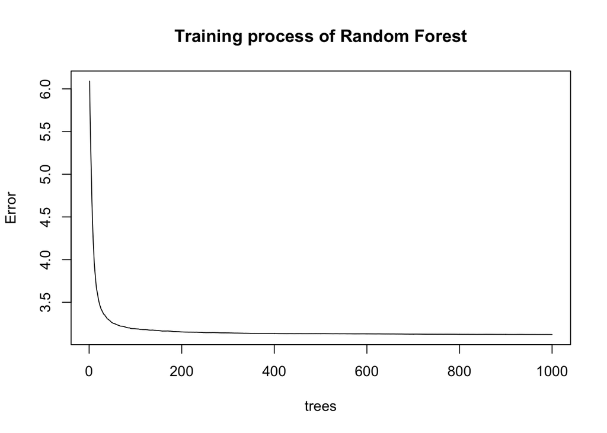

```r
set.seed(20)

#Random forest model
model_rf <- randomForest(target ~ . - judge - card_id - first_active_month - purchase_earlest_month, data = train_data, ntree = 1000, importance = TRUE)

#Plot the training process
plot(model_rf, main = "Training process of Random Forest")
```

```r
# GBDT model

library(gbm)
model_gbdt <- gbm(target ~ .-judge- first_active_month - card_id - purchase_earlest_month, data = train_data, n.trees = 1000, shrinkage = 0.01, distribution = "gaussian", cv.folds = 5)
```

```r
#plot loss function as a result of n trees added to the ensemble
gbm.perf(model_gbdt, method = "cv")
```

```
## [1] 866
```

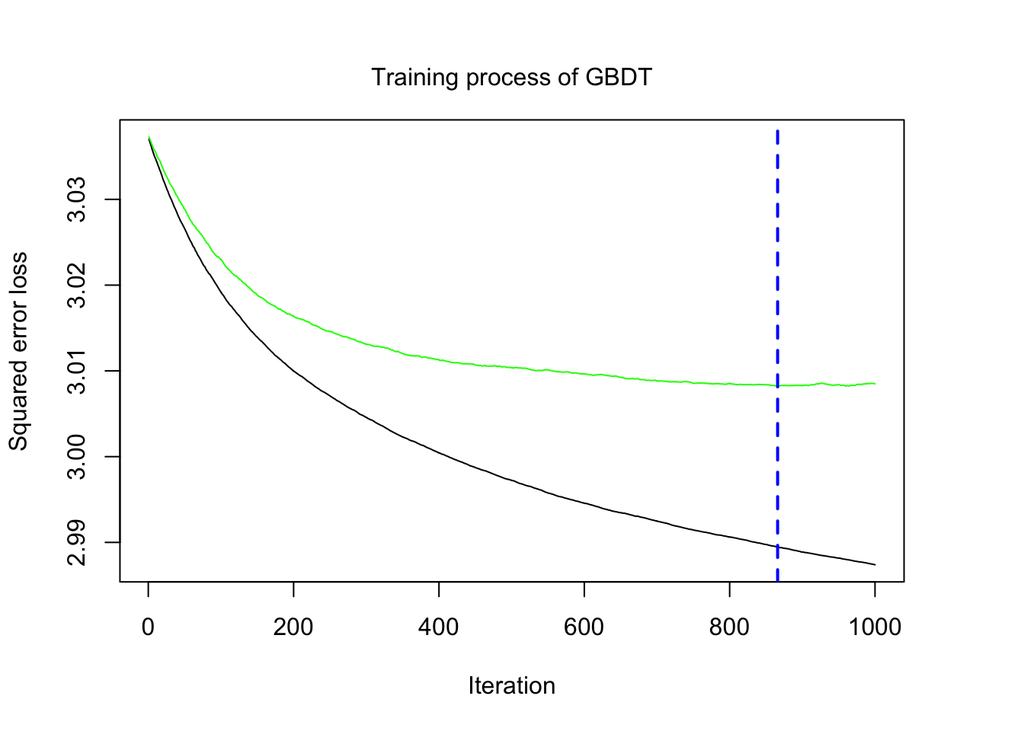

```r
mtext("Training process of GBDT", line = 1)
```

The plot of RF shows the Mean Squared Error and the number of trees. The error drops when more trees are added. The error rate stabalizes around 100 trees but continues to decrease slowly. The plot of GBDT model shows that the train error (black line) decreases with the increase of iteration while the error rate by the cross-validation (green line) goes down firstly and increases slowly later on. The optimal number of iterations is around 800 as indicated by the blue line. These two plots show the process of how models are trained and errorness are reduced. The optimal number of trees in models will be applied on test data to predict the customer loyalty score.

2.3.2 Importance ranking

```r
#Use varImp() to calcuate importance of each feature of RF

library(caret)
```

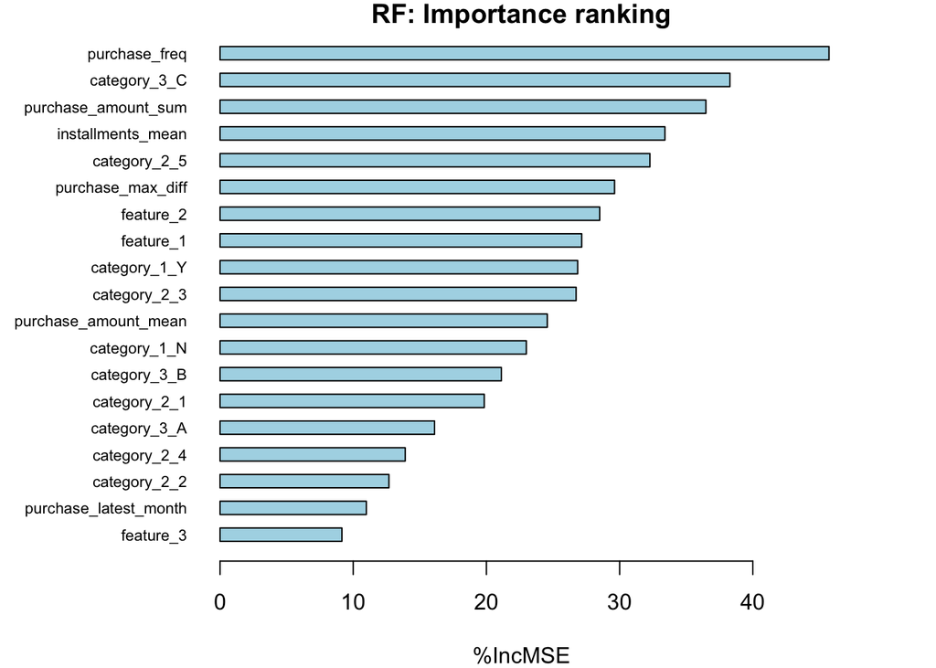

```r
imp <- varImp(model_rf)

#compare with importance based on node purity
imp <- as.data.frame(imp)
imp$features <- rownames(imp)

#rank the importance of features
imp <- imp[order(imp[,1]),]

#Barplot for importance ranking
par(mar = c(4,8,1,4) )
barplot(imp$Overal, main = "RF: Importance ranking", horiz = TRUE, names.arg = imp$features, las = 1, space = c(1,1,1,1), cex.names = 0.7, xlab = "%IncMSE", col = "lightblue")
```

```r
#summary table of GBDT
par(mar = c(2, 11, 1, 1))
summary(model_gbdt, method = relative.influence, n.trees = which.min(model_gbdt$cv.error), las = 2, cBars = 15)
```

```
##                                         var     rel.inf
## purchase_latest_month purchase_latest_month 30.57424455
## purchase_freq                 purchase_freq 24.05418160
## purchase_amount_mean   purchase_amount_mean 11.60203484
## purchase_amount_sum     purchase_amount_sum 10.82099855
## purchase_max_diff         purchase_max_diff  5.67367668
## installments_mean         installments_mean  5.24820606
## category_1_Y                   category_1_Y  2.72822226
## category_1_N                   category_1_N  2.02108625
## category_3_A                   category_3_A  1.19676311
## category_2_1                   category_2_1  1.18805268
## category_2_3                   category_2_3  1.17749808
## feature_1                         feature_1  1.13573346
## category_2_5                   category_2_5  0.96007756
## category_2_4                   category_2_4  0.71888465
## feature_2                         feature_2  0.39439939
## category_2_2                   category_2_2  0.31337248
## category_3_C                   category_3_C  0.12390561
## category_3_B                   category_3_B  0.06866218
## feature_3                         feature_3  0.00000000
```

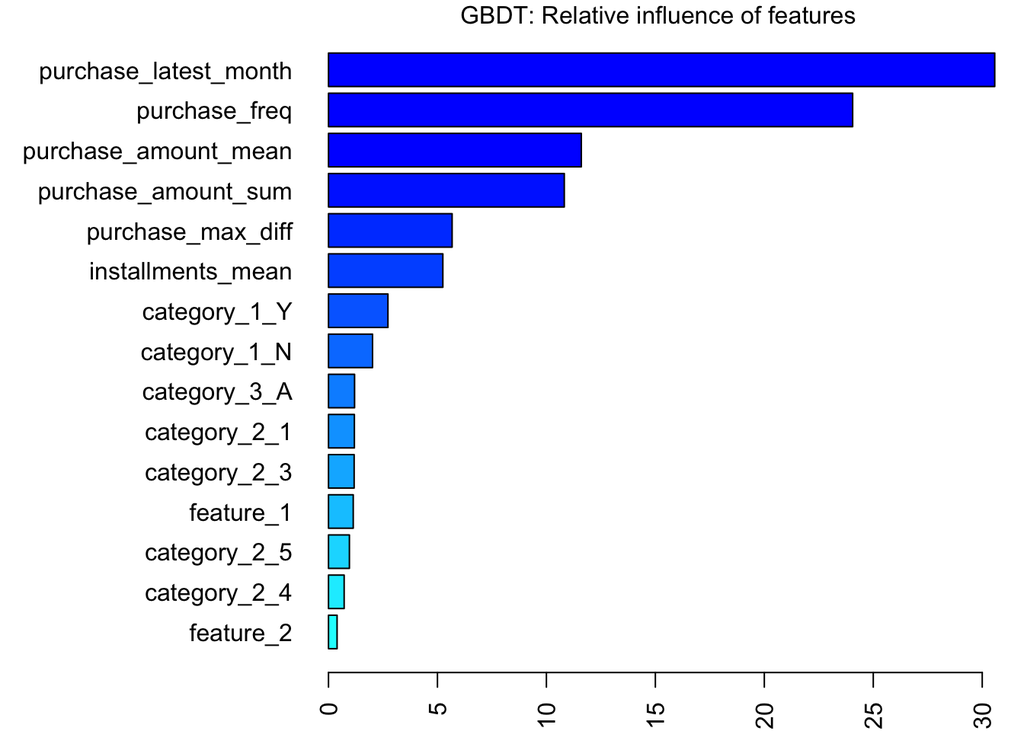

```r
mtext("GBDT: Relative influence of features")
```

*I do not use the summary function of RF model because the summary function for random forest object is not implemented well. It just prints out some internal variables and their types.

2.3.3 Residuals visualization

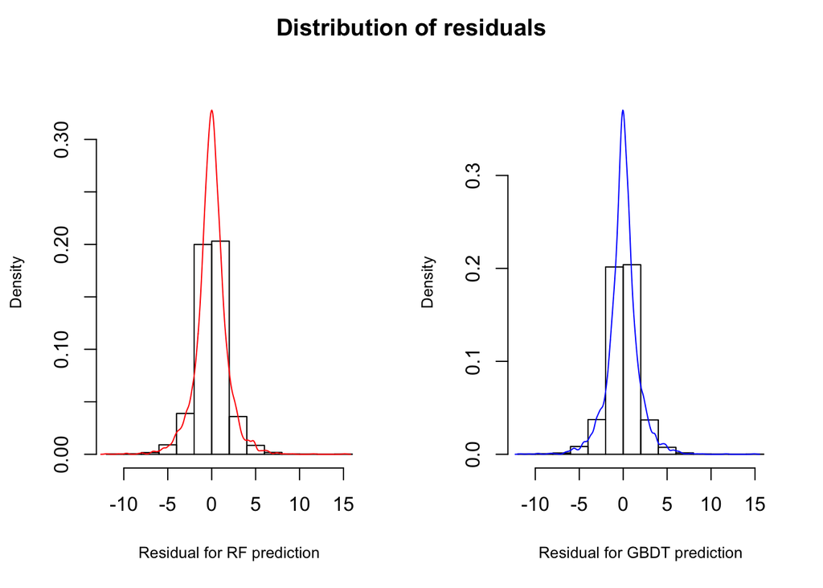

```r
#residuals for each model

y_test <- test_data$target

#prediction of RF
pred_rf<- predict(model_rf, newdata = test_data, type = "response")

#prediction of GBDT
pred_gbdt <- predict(model_gbdt, newdata = test_data, n.trees = which.min(model_gbdt$cv.error), type = "response")

residual_rf <- y_test - pred_rf

residual_gbdt <- y_test - pred_gbdt

#plot the residual distribution

tmp1 <- density(residual_rf)
tmp2 <- density(residual_gbdt)

par(mfrow = c(1,2))
hist(residual_rf, prob = TRUE, xlab = "Residual for RF prediction", main = NULL, cex.lab = 0.8, ylim = c(0, max(tmp1$y)))
lines(tmp1, col = "red")
hist(residual_gbdt, prob = TRUE, xlab = "Residual for GBDT prediction", main = NULL, cex.lab = 0.8, ylim = c(0, max(tmp2$y)))
lines(tmp2, col = "blue")
title("Distribution of residuals", outer = TRUE, line = -1.5)
```

```r
rm(tmp1)
rm(tmp2)
```

The two plots are similar. The histogram of the residuals on test data distributed in a bell shape and centred around zero indicates that the regression model predicts and makes mistakes in a random manner and does not systematically over or under predict any particular range of target values. Thus we can accept both regression models for this research question.

3 Validation statistics

Root Mean Square Error (RMSE) is a commonly used evaluation method for regression problems.

```r
#prediction of RF
pred_rf<- predict(model_test2, newdata = test_data, type = "response")

#optimal number of trees of RF
trees_rf = which.min(model_test2$mse)

#correspondant RMSE of RF
rmse_rf_cv = sqrt(model_test2$mse[trees_rf])

#RMSE on test data of RF
rmse_rf_test = sqrt(mean((test_data$target - pred_rf)^2))

#prediction of GBDT
pred_gbdt <- predict(model_test4, newdata = test_data, n.trees = which.min(model_test4$cv.error), type = "response")

#optimal number of trees of GBDT
trees_gbdt = which.min(model_test4$cv.error)

#correspondant RMSE of GBDT
rmse_gbdt_cv = sqrt(model_test4$cv.error[trees_gbdt])

#RMSE on test data of GBDT
rmse_gbdt_test = sqrt(mean((test_data$target - pred_gbdt)^2))

#print("Optimal number of trees of RF:")
trees_rf
```

[output not shown]

```
## [1] 979
```

```r
#print("RMSE of RF on cross validation:")
rmse_rf_cv
```

```
## [1] 1.769222
```

```r
#print("RMSE of RF on test data:")
rmse_rf_test
```

```
## [1] 1.7969
```

```r
#print("Optimal number of trees of GBDT:")
trees_gbdt
```

```
## [1] 726
```

```r
#print("RMSE of GBDT on cross validation:")
rmse_gbdt_cv
```

```
## [1] 1.734621
```

```r
#print("RMSE of GBDT on test data:")
rmse_gbdt_test
```

```
## [1] 1.757183
```

```r
#The best model is model_test4 (GBDT model)

par(mar = c(2, 11, 1, 1))
summary(model_test4, method = relative.influence, n.trees = which.min(model_test4$cv.error), las = 2, cBars = 10)
```

```
##                                         var    rel.inf
## purchase_latest_month purchase_latest_month 31.7570437
## purchase_freq                 purchase_freq 27.6831979
## purchase_amount_mean   purchase_amount_mean 10.4856608
## purchase_amount_sum     purchase_amount_sum  9.6239728
## purchase_max_diff         purchase_max_diff  5.6572320
## installments_mean         installments_mean  5.2490318
## category_1_N                   category_1_N  2.5635047
## category_1_Y                   category_1_Y  2.5605752
## category_2_1                   category_2_1  1.4127067
## feature_1                         feature_1  1.3604253
## category_2_3                   category_2_3  0.8755154
## category_3_A                   category_3_A  0.7711336
```

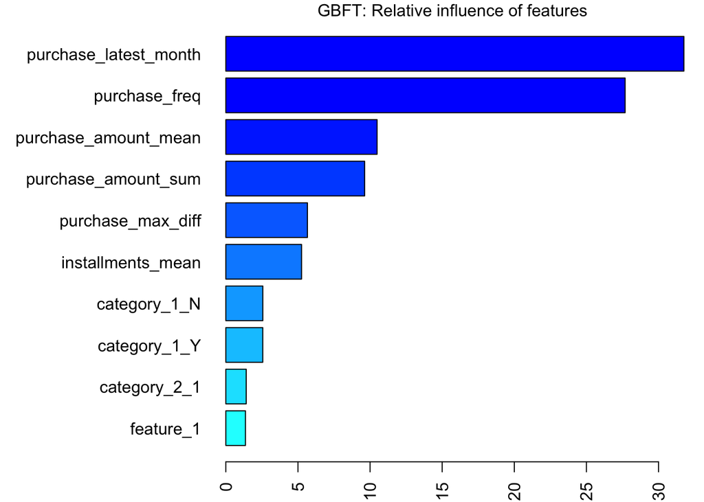

```r
mtext("GBFT: Relative influence of features")
```

Besides, we can comparing the performance of these two algorithms. RF usually have good and steady performance on general classification or regression problems. However, RF does not perform as well on regression as on classification problems because it cannot predict scores out of the range of training data scores. Instead, GBDT uses regression trees for each node. The RMSE of two models shows that GBDT tends to have better performance for this regression problem.

4 Discussion

Firstly, there are some important parameters to be tuned(learning rate in gradient boosting decision trees, maximum number of leaf nodes, the depth of each tree, the number of trees in both algoritms, etc.). We can apply grid search to fine tune these models.

Secondly, more work can be done on features selection. The dataset of merchant information hasn’t been used. It can help analyze the customer purchase behaviour and the effect of some potential merchant features on loyalty scores, but it will probably increase the computational time and the complexity of the model drasticly.